# Reproducible Research Project1

rlbasu

January 24, 2017

### Introduction

This assignment makes use of data from a personal activity monitoring device. This device collects data at 5 minute intervals through out the day. The data consists of two months of data from an anonymous individual collected during the months of October and November, 2012 and include the number of steps taken in 5 minute intervals each day.

### Data

The data was downloaded from the course web site:

- Dataset: [Activity Monitoring Data](https://d396qusza40orc.cloudfront.net/repdata%2Fdata%2Factivity.zip) [52K]

The variables included in this dataset are:

- **steps**: Number of steps taking in a 5-minute interval (missing values are coded as `NA`)
- **date**: The date on which the measurement was taken in `YYYY-MM-DD` format
- **interval**: Identifier for the `5-minute` interval in which measurement was taken

The dataset is stored in a comma-separated-value (`CSV`) file and there are a total of 17,568 observations in this dataset.

### Loading Data

```r
Activity = read.csv("activity.csv")
```

### What is mean total number of steps taken per day?

Calculate the total number of steps taken per day and plot histogram

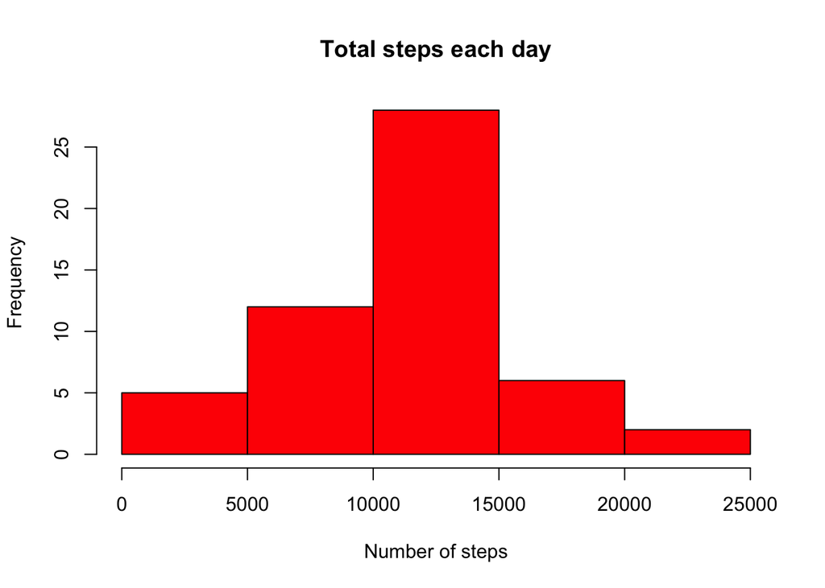

```r
stepsDay = aggregate(steps ~ date, Activity, sum)
hist(stepsDay$steps, main = "Total steps each day", col = "red", xlab = "Number of steps")
```

Calculate mean and median

```r
Mean = mean(stepsDay$steps)
Median = median(stepsDay$steps)
```

### What is the average daily activity pattern?

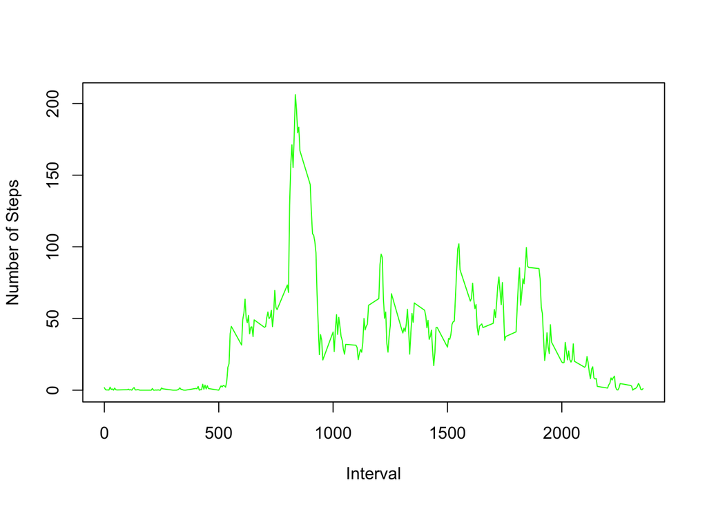

```r
StepsInterval = aggregate(steps ~ interval, Activity, mean)
plot(StepsInterval$interval, StepsInterval$steps, type = "l", col= "green", xlab = "Interval", ylab = "Number of Steps")
```

```r
Maxint = StepsInterval[which.max(StepsInterval$steps), 1]
```

### Impute missing values. Compare imputed to non-imputed data.

Calculate and report the total number of missing values in the dataset (i.e. the total number of rows with NAs)

```r
Missing = sum(!complete.cases((Activity)))
```

The total no of missing values in steps as ‘NA’ is 2304.

```r
Imputed = transform(Activity, steps = ifelse(is.na(Activity$steps), StepsInterval$steps[match(Activity$interval, StepsInterval$interval)], Activity$steps))
```

Zeroes were imputed for 10-01-2012 because it was the first day and would have been over 9,000 steps higher than the following day, which had only 126 steps. NAs then were assumed to be zeros to fit the rising trend of the data.

```r
Imputed[as.character(Imputed$date) == "2012-10-01", 1] = 0
```

Create new dataset but with the missing data filled in and plot histogram

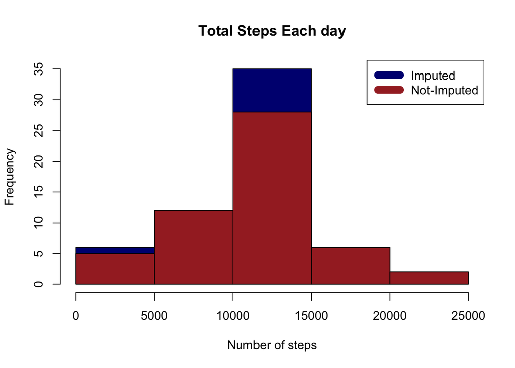

```r
stepsDayNew = aggregate(steps ~ date, Imputed, sum)
hist(stepsDayNew$steps, main = "Total Steps Each day", xlab = "Number of steps", col = "navy")

hist(stepsDay$steps, main = "Total Steps Each day", xlab = "Number of steps", col = "brown", add = TRUE)
legend("topright", c("Imputed", "Not-Imputed"), col = c("navy", "brown"), lwd = 10)
```

Calculate mean and mediam for imputed data

```r
NewMean = mean(stepsDayNew$steps)
NewMedian = median(stepsDayNew$steps)
```

Calculate difference between imputed and non-imputed data.

```r
DiffMean = NewMean - Mean
DiffMedian = NewMedian - Median
```

Calculate total difference.

```r
Diff_tot = sum(stepsDayNew$steps) - sum(stepsDay$steps)
```

### Are there differences in activity patterns between weekdays and weekends?

New factor variable is craeted in the dataset with two levels – “weekday” and “weekend” indicating whether a given date is a weekday or weekend day.

```r
weekdays = c("Monday", "Tuesday", "Wednesday", "Thursday", "Friday")
Imputed$dow = as.factor(ifelse(is.element(weekdays(as.Date(Imputed$date)), weekdays), "Weekday", "Weekend"))
stepsIntevalNew = aggregate(steps ~interval + dow, Imputed, mean)
```

plot to compare number of steps in weekdays and weekend.

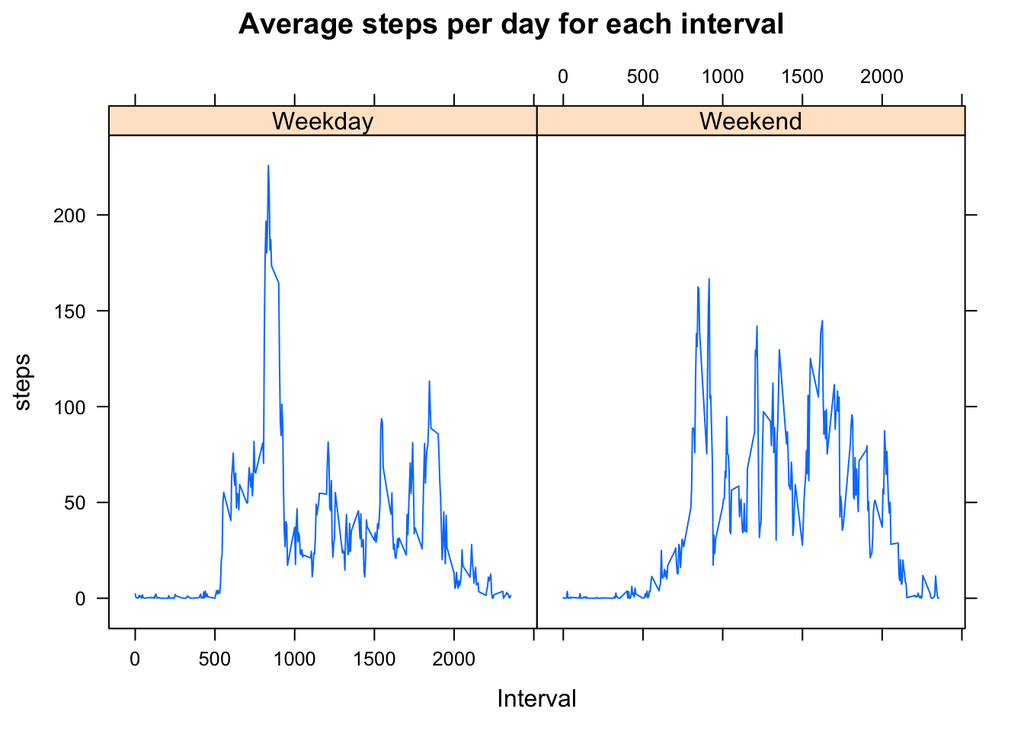

```r
library(lattice)
xyplot(stepsIntevalNew$steps ~ stepsIntevalNew$interval | stepsIntevalNew$dow,type = "l",layout= c(2,1),xlab = "Interval", ylab = "steps",main = "Average steps per day for each interval")
```